# Play With Sound File With Python

presented by Haoyu Yan

This is a research project that discovers ways to manipulate sound files in wav. format with python packages from anaconda. I did this project because I like music and playing with computer, and I'd like to try to play with music using some coding techniques. In this project, I will show a couple of differenet ways to make changes to a sound file. The environment it follows under is Python 3 and Jupiter Notebook.

Before we get started, It's important to know what sound is. Sound is essentially a type of signal caused by vibrations that can travel through mediums, and such vibration can be interpreted to be a wave. There are two major elements by which a wave can be examined, the amplitude and the frequency.

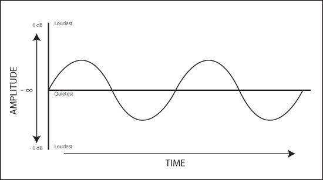

The amplitude is the maximum displacement reached by a wave, and the amplitude of a sound wave determines the loudness of the sound. The frequency of a wave refers to the number of cycles occurs in a specific period of time, typically one second. The frequency determines the pitch of the sound. Therefore, by changing the amplitude or the frequency of a sound file, we can easily modify its volume and tone.

# import libraries and input sound file

The first step is to import the libraries. The packages we use are numpy, matplotlib, scipy and IPython. These can be downloaded from anaconda.

```python
import numpy as np
import matplotlib.pyplot as plt
from scipy.io.wavfile import read,write
from IPython.display import Audio
from numpy.fft import fft, ifft
%matplotlib inline
```

scipy.io.wavfile allows us to read a sound file within WAV. format. The WAV file is one of the simplist digital file formats, and it works by converting a sound signal into binary data. We can see what the data is like by printing its "shape", in this case, it has two rows with 7431872 digits for each, in another word, it's a 7431872*2 array. The two rows are essentially two channels (left and right) within the sound file. The sampling frequency, Fs for this sound file is 48000, means there are 48000 digits being processed per second. Note that the sampling frequency is not the same as the frequecy of sound.

```python
Fs, data= read('coffindance.wav')
print(data.shape)
print(Fs)
```

```
(7431872, 2)
48000
```

# plot the wave

Using matplotlib, we can interpret sound by a graph.

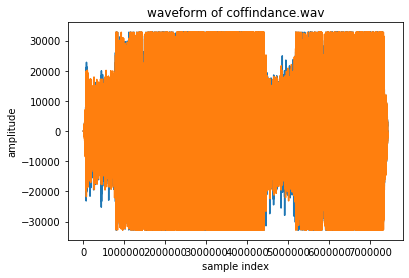

```python
plt.figure()
plt.plot(data)
plt.xlabel("sample index")
plt.ylabel("amplitude")
plt.title("waveform of coffindance.wav")
plt.show()
```

In the graph above, the x-axis is made to be the sample index, or the digits within each channel. The y-axis represents the amplitude, or the magnitude of each digit. The two channels are indicated by two different waveforms in different colors.

# cut the sound

We can cut the sound by redefining "data". Because sound in WAV file is interpreted as number sequences, by removing a number of digits from the number sequence we can delete part of the sound. In the code below, data=data[:,1] redefines data as all the digits within channel 1, thus only keeps channel 1. If we print data there it shows (7431872,), indicates that data turns to be a one-dimension number sequence instead of a two-dimension matrix, only a single channel is left.

```python
data=np.array(data)
data=data[:,1]
print(data.shape)
```

```
(7431872,)
```

use IPython.display to play the audio

```python
#Audio(data,rate=Fs)
```

We can further remove numbers from data to reduce its length. The code data=data[0:540000] modifies data once again, and it keeps the first 5400000 digits among all 7431872 digits, so data.shape becomes (5400000,). When we try to play the audio again, it goes noticeably shorter.

```python
data=data[0:5400000]
print(data.shape)
#Audio(data,rate=Fs)
```

```
(5400000,)
```

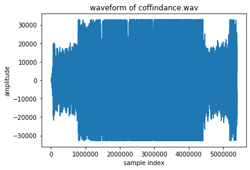

```python
plt.figure()
plt.plot(data)
plt.xlabel("sample index")
plt.ylabel("amplitude")
plt.title("waveform of coffindance.wav")
plt.show()
```

# manipulate the intensity of the sound

Remind that the magnitude of the digits determines the intensity of the sound. Therefore, the intensity can be manipulated by changing values of numbers within the number sequence. The easiest way is to just multiply the data with a ratio. For example, if we want to make the first 3700000 numbers increase by half, we can just do the following code: data[0:3700000]=data[0:3700000]*1.5. It replaces the part of data from digit 0 to digit 3700000 by 1.5 times the original values, making the specific section of the audio become louder when we play it.

```python
data[0:3700000]=data[0:3700000]*1.5
#Audio(data[0:3700000], rate=Fs)
```

It's also possible to make a gradual change in valume. One way to achieve it is to use a loop to help us modify many small pieces of sound. In the code below, we created a slow decrease of amplitude from digit 3700000 to digit 5400000, thus gradually muted the music.

```python
a=3700000
b=3701000
c=1
for i in range(0,1699):
    a=a+1000
    b=b+1000
    c=c+0.01
    data[a:b]=data[a:b]/c
#Audio(data[3700000:5400000], rate=Fs)
```

We can clearly see the changes from the graph of the new modified music. Its amplitude changes just as we expected.

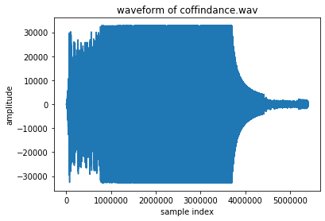

```python
plt.figure()
plt.plot(data)
plt.xlabel("sample index")
plt.ylabel("amplitude")
plt.title("waveform of coffindance.wav")
plt.show()
```

# manipulate the frequency of the sound

The frequency of the sound determines the pitch. By manipulating the frequency, we can change the music itself. Because the first sound file has been modified, we input another file here, and keep only one channel for simplicity.

```python
fS,DATA= read('xuehuapiaopiao.wav')
print("sampling frequency#2 is",fS)
DATA=DATA[:,0]
print(DATA.shape)
#Audio(DATA,rate=fS)
```

```
sampling frequency#2 is 48000
(10846558,)
```

The first way to manipulate the frequency of the sound is to change the sampling frequency. The sampling frequency, again is the rate by which digits in a WAV file are processed. The following code multiplies the sampling frequency by 1.5.

```python
fS= fS*1.5
#Audio(DATA,rate=fS)
```

Because the sampling frequency is a specific number, we can also just define it as a random integer.

```python
fS=47000
```

Another method to manipulate frequency is called fourier transform. By using numpy, it allows us to decompose a complicated wave into multiple waves with different frequencies. The following code defines DATA_F as the decomposed DATA, and it's printed as a number of waves, arranged from low frequency to high frequency.

```python
print(DATA.shape)
fft(DATA)
DATA_F=fft(DATA)
print(DATA_F)
print(DATA_F.shape)
```

```
(10846558,)
[-2.81975589e+08-4.28408384e-08j  4.03636978e+07-4.68615939e+07j
  2.65784947e+07-6.96256607e+07j ...  7.76274777e+07-4.89918439e+07j
  2.65784947e+07+6.96256607e+07j  4.03636978e+07+4.68615939e+07j]
(10846558,)
```

```python
DATA_F[20000:,]=0
DATA_F[:10000,]=0
print(DATA_F)
DATA_processed=ifft(DATA_F)
DATA_processed=np.real(DATA_processed)
```

```
[0.+0.j 0.+0.j 0.+0.j ... 0.+0.j 0.+0.j 0.+0.j]
```

And the graph gets quite different as plotted. Any sound out of the range has been removed.

```
<function matplotlib.pyplot.show(*args, **kw)>
```

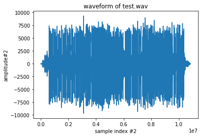

```python
plt.figure()
plt.plot(DATA_processed)
plt.xlabel("sample index #2")
plt.ylabel("amplitude#2")
plt.title('waveform of test.wav')
plt.show
```

Actually, you can hardly hear any sound now, because we kept frequency within a really tiny range.

```python
#Audio(DATA_processed,rate=Fs)
```

We can try to redo it, and remove the high pitched flute in the beginning. (we have to redefine DATA_F to make it restored to the original)

```python
DATA_F=fft(DATA)
DATA_F[190000:,]=0
#Audio(DATA_processed,rate=Fs)
```

# sum up two sounds

In order to sum up two sounds, we can simply add "data" together; but they must have the same length. For example, if we are to combine "coffindance.wav" and "xuehuapiaopiao.wav", we should first cut them to the same length and sum up "data" and "DATA".

```python
DATA=DATA[0:5400000]
```

Use another variable to name the new sound, and play it:

```python
DaTa=data+DATA
#Audio(DaTa, rate=Fs)
```

The new sound turns to be a combination of those two.

# Conclusion

To write the edited audio as a output:

```python
write('output.wav',Fs,DaTa)
```